# Web Mapping & Visualisation

The Web’s Architecture and Economy

Matthew Howard, Elisabetta Pietrostefani & Daniel Arribas Bel

## Today

- A (brief an opinionated) history of the Web
- The server/client model
- The modern web mapping eco-system
- API overview

## A (brief and opinionated) history of Web trends

[Inspired by…](https://www.internetsociety.org/internet/history-internet/brief-history-internet/)

## Pre 1970s

The seeds:

- US (e.g. Licklider’s “Galactic Network”)
- Mostly military contracts (e.g. D/ARPA –> ARPANET) and “research’y”
- Develop protocols for machine communication

## 1970s - Birth of the *internet*

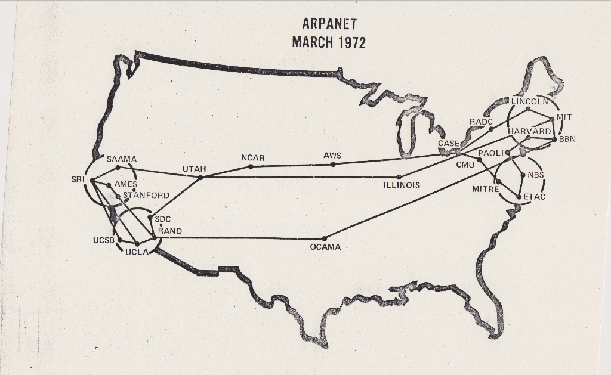

## 1980s

- Growth of the “web”
- From experimental validation to scaled up insfrastructure
- Free software (e.g. “Free as in Freedom”)

## 1990s

- Civilian and commercial growth
- Web 1.0
- Open Source software (e.g. “The cathedral and the Bazaar”)

## 2000s

- Web 2.0
- Mobile
- Web mapping takes off (hello Google Maps!)

## 2010s

- Consolidation of ‘GAFA’ –> concentration
- IoT
- Death of the desktop?

## 2020s

- Web3
- Government regulation and legislation
- AI

## Ideas to retain

- The Web is technology to build decentralised systems
- Economics (for the most part) have turned it into a concentrated economy
- Computing today is physically distributed but socio-economically concentrated

## The server/client model

[figure not shown]

## Benefits

- Interoperability of disparate platforms
- Optimise on hard/software for each task (“distribute”)
- Separate data collection (e.g. sensor), storage (e.g. data centre), intensive computing (e.g. compute cluster), interaction (e.g. mobile)

## Disadvantages

- Requires (cheap & ubiquitous) connectivity
- More complex than an isolated approach (e.g. desktop)
- Harder to “keep afloat”

## Building blocks of a web map

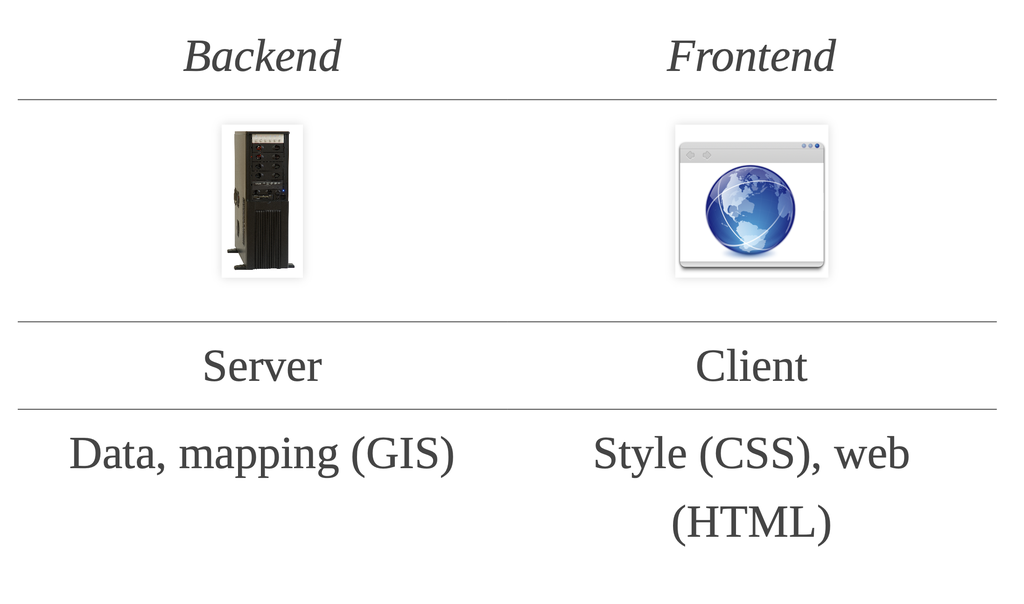

## The current web mapping landscape

## Structure

- **Software**: a lot of open-source projects
- **Platforms**: a concentrated few (web infrastructure is hard and expensive!)
- **Business model**: software as a service

## The trade off…

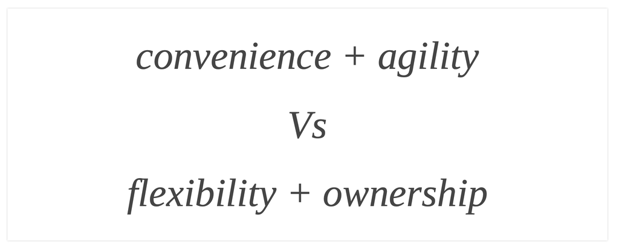

**This course**: Not focused on engineering the backend/infastructure, prioritises frontend design/development

## Data challenges

- Bias (Who is/isn’t represented?)
- Licensing (Who controls the data, what can you do with it?)
- Access (How technically complex is to use?)

D. Arribas Bel (2014), Accidental, open and everywhere: Emerging data sources for the understanding of cities

## APIs

## What do APIs actually do?

- Application Programming Interfaces (“APIs”)
- Instead of having to download a data set, APIs allow you to request (parts of) a database directly from a remote server to a local machine.

When you work with web APIs, two different computers - **a client and server** - will interact with each other to request and provide data, respectively.

[figure not shown]

## Web API structure

- Often require Authentication using tokens (potentially linked to billing)
- Adhere to a particular style known as Representation State Transfer or REST (in most cases)
- RESTful APIs are convenient because we use them to query database using URLs over HTTP

## Accessing APIs

**Plug-n-play packages.** Many common APIs are available through user-written Py libraries.

**Writing our own API request.** If no wrapper function is available, we have to write our own API request and format the response ourselves.

## Week 3 Lab Content

**Main Goal:** Testing out example APIs and access methods:

- ‘Plug-n-Play’ API packages with the *Census* package.
- Writing our own requests looking at bike sharing in London.
- Spatial data APIs (OSM data using the geocoder from *geopy*)

Web Mapping and Visualisation by [Elisabetta Pietrostefani](http://pietrostefani.com) is licensed under a [Creative Commons Attribution-ShareAlike 4.0 International License](http://creativecommons.org/licenses/by-sa/4.0/).